# Aside

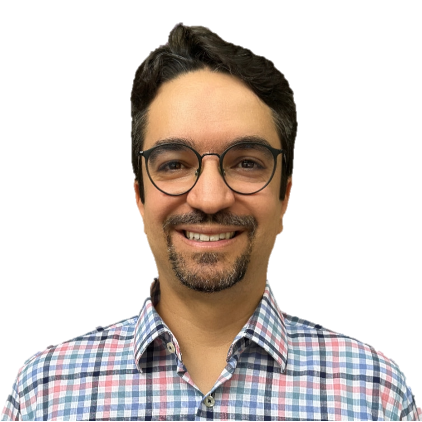

## Contact Info

- rapdornas@gmail.com
- github.com/rdornas
- +1 (352) 709-0128
- For more information, please contact me via email.

## Skills

• Experienced in field biology and ecology, with a focus on wildlife and road/railroad ecology

• Proficient in R for data analysis and geoprocessing; experienced in web application development with Ruby on Rails

• Active in IT projects since 2017

## Disclaimer

Last updated on Sep 29, 2026.  
Updated CV at rdornas.github.io/CV

# Main

## Rubem Dornas

### Biologist and Digital Product Professional Bridging Science, Technology, and Business

I hold a BSc. in Biological Sciences from Universidade Federal de Minas Gerais (UFMG), Brazil, along with a specialization in Geoprocessing from Pontifícia Universidade Católica de Minas Gerais (PUC-MG) and an MSc. in Analysis and Modeling of Environmental Systems from UFMG. With over fifteen years of experience in environmental consulting for leading regional and global firms, I developed strong skills in data analysis and technical writing. I have also authored and peer-reviewed scientific publications on environmental topics. More recently, I have transitioned into the IT domain, where I operate at the intersection of data, technology, and product development. I contribute to data analysis workflows, support development teams, and act as a Product Owner/Business Analyst.

## Education

### Universidade Federal de Minas Gerais

MSc. in Analysis and Modeling of Environmental Systems

Belo Horizonte, Brazil

2019 - 2017

Thesis: Estimations and temporal and spatial patterns of fatalities of cane toads (*Rhinella* gr. *marina*) on Brazilian Amazonian railroad (in Portuguese)

### Pontifícia Universidade Católica de Minas Gerais

Specialization in Geoprocessing

Belo Horizonte, Brazil

2018 - 2016

Thesis: Geoprocessing applied to the environment area: a case study based on quantitative methods of spatial analysis (in Portuguese)

### Universidade Federal de Minas Gerais

BSc. in Biological Sciences - Vertebrates’ Zoology

Belo Horizonte, Brazil

2010 - 2008

Thesis: Study of wild vertebrates road-kills on Serra do Rola-Moça State Park, Minas Gerais (in Portuguese)

### Universidade Federal de Minas Gerais

BSc. (Teaching Licensure) in Biological Sciences

Belo Horizonte, Brazil

2007 - 2003

Thesis: Peculiarities, curiosities and myths of birds as a tool for basic teaching of Ornithology (in Portuguese)

## Professional Experience (last 3)

### Biologist / Digital Project Coordinator

AECOM

Belo Horizonte, Brazil

Current - 2020

- Involved in auditing of mining tailings dams
- Preparation of technical reports and presentations
- Creation, development and maintenance of a digital platform for audit recommendation tracking, including hands-on coding
- Product Owner / Business Analyst of an internal digital tool related to responsible mining

### Data Scientist

Amplo Engenharia e Gestão de Projetos

Belo Horizonte, Brazil

2020

- Planning and elaboration of digital forms for field data collection
- Planning and elaboration of computational scripts and packages in R programming for extracting and including information in relational databases
- Data analysis and report writing

### Biologist

Amplo Engenharia e Gestão de Projetos

Belo Horizonte, Brazil

2017 - 2011

- Member of the technical and coordination teams concerning several environmental studies related to mining and transportation.
- Responsible for the fauna studies needed to the expansion of Estrada de Ferro Carajás (EFC), under concession by Vale S.A.
- Responsible for presentations on behalf of the company to different audiences

## Selected Publications

### Giant anteaters on the move: native habitat selection and behavioral responses to land use change

Movement Ecology. 14:2

[figure not shown]

N/A

2026

Meiga AYY, Desbiez ALJ, **Dornas RAP**, Attias N, Giroux A & Valle D.

### Camera trap surveys of Atlantic Forest mammals: A data set for analyses considering imperfect detection (2004-2020)

Ecology. 105:e4298.

[figure not shown]

N/A

2024

Franceschi IC, **Dornas RAP**, Lermen IS, et al.

### The need to consider searcher efficiency and carcass persistence in railway wildlife fatality studies

European Journal of Wildlife Research. 66:81.

[figure not shown]

N/A

2020

Dasoler BT, Kindel A, Beduschi J, Biasotto LD, **Dornas RAP**, Gonçalves LO, Lombardi PM, Menger T, de Oliveira GS & Teixeira FZ.

### Strain by the train: Patterns of toad fatalities on a Brazilian Amazonian railroad

Science of the Total Environment. 660:493-500.

[figure not shown]

N/A

2019

**Dornas RAP**, Teixeira FZ, Gonsioroski G & Nóbrega RAN.

### On a collision course: the vulnerability of bats to roadkills in Brazil

Mastozoologia Neotropical. 25(1):115-128.

[figure not shown]

N/A

2018

Novaes RLM, Laurindo RS, **Dornas RAP**, Esbérard CAL & Bueno C.

### Record of the Giant Otter, *Pteronura brasiliensis* (Zimmermann, 1780), (Carnivora: Mustelidae) in a fragmented landscape of Maranhão state, Brazil

Checklist. 13(1):2041.

[figure not shown]

N/A

2017

Prist PR, **Dornas RAP**, dos Santos RH, Torres LGC & Lima ELP.

## Other relevant information

- Reviewer for several academic journals.
- Multiple concluded works for environmental companies as a senior consultant.
- Active member of NERF / UFRGS - Núcleo de Ecologia de Rodovias e Ferrovias / Universidade Federal do Rio Grande do Sul.
- French:
  - Diplôme Approfondi de Langue Française / DALF (2003).
  - TEF Canada (2026) - CECR Level: Compréhension écrite C1 / Compréhension orale C2 / Expression écrite B2 / Expression orale C1
- English: IELTS (2026) - CEFR Level: C1